# Here’s the Kicker

Correcting Selection Bias in NFL Field Goal Models via Inverse Probability Weighting

Elliott Kervin

University of North Carolina at Charlotte

Michael Schuckers

University of North Carolina at Charlotte

September 12, 2026

## Coaches choose which kicks we see

Field goal models adjust attempts for difficulty. Distance first, then weather, venue, game state.

All of them are fit on kicks a coach agreed to take.

Coaches decline potential kicking opportunities in favor of punting or going for it on fourth down.

These decisions are not random. Actual attempts represent a selected group, overrepresenting favorable kicking scenarios.

If a coach believes they have information about their kicker’s ability, that belief can shape which kicks get attempted, information no outcome model observes directly.

## Three questions

1. Is the attempt decision **structured enough** to model?
2. Does adding the declined kicks back with **pseudo-miss labels** help?
3. Does **inverse probability weighting** improve out-of-sample prediction?

And if the answer to two and three is no, what does that tell us about why coaches decline?

## The analysis sample

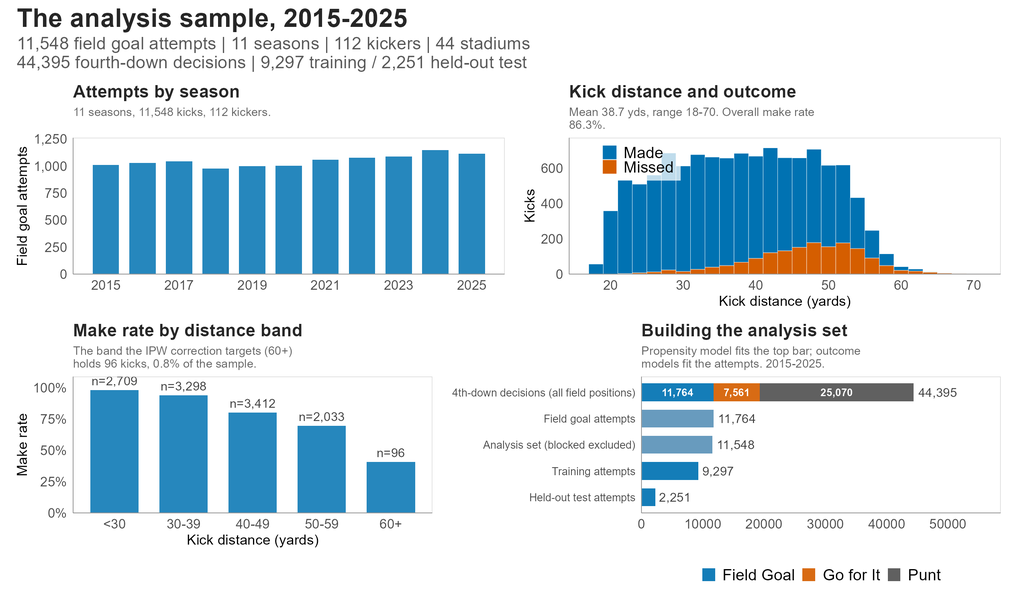

## Kickers have improved past 45 yards

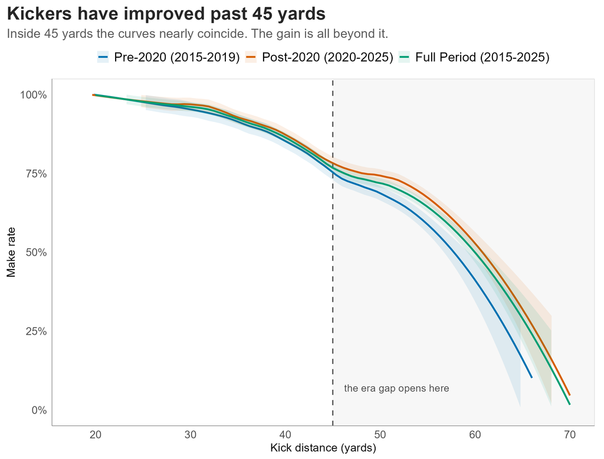

~202 additional makes

in 2020 to 2025, against the pre-2020 success curve

~34 makes per season

and ~148 of the ~202 come from beyond 45 yards

Inside 45 yards the curve was already close to its ceiling. The improvement is concentrated in the long tail.

## Coaches are asking for longer kicks

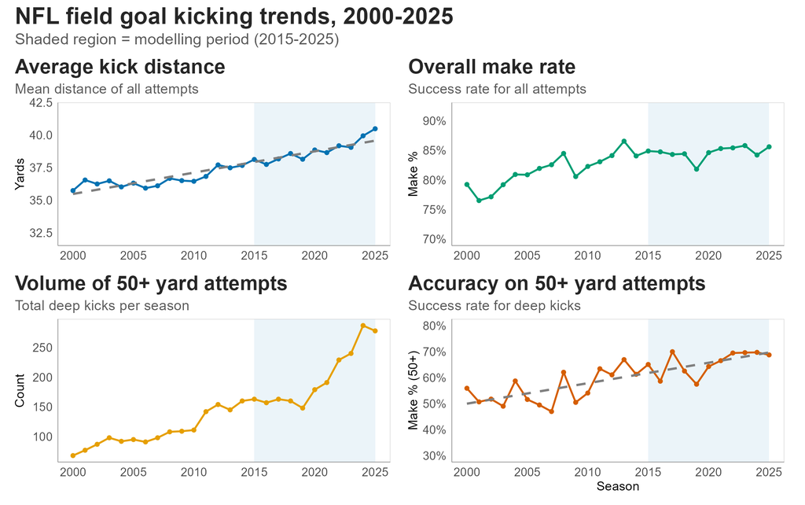

## Four outcome models

### M0 distance only

B-spline in distance. Nothing else.

*The predictive floor.*

### M1 full GLMM

M0 plus weather splines, contextual indicators, kicker-season and stadium random intercepts. Unweighted.

*The baseline.*

### M2 augmented

M1 fitted on an augmented set. PATs with real outcomes, declined fourth downs as pseudo-misses, both at reduced weight.

*Impute the unobserved attempts.*

### M3 IPW

M1 fitted with stabilized IPW case weights.

*Reweight instead of impute.*

Every row carries an observed outcome. The price is variance, not bias.

## Modeling the attempt decision

**Multinomial logit** over kick, punt, go. Reference category is go for it.

- Natural spline on **field position** $\text{yl}_i$, full field 1 to 100
- **Log game seconds remaining** $\log(1 + t_i)$, quarter-time interactions
- Yards to go $\text{ytg}_i$; score state, venue, wind, temperature $\mathbf{S}_i$
- **Leverage** $L_i$, the win probability after a make minus the win probability after a miss, estimated before the outcome is known

**Rolling origin.** Train on seasons $s{-}3, s{-}2, s{-}1$, predict season $s$.

**AUC 0.933 to 0.959** in plausible kicking range, every season

**RMSE 0.045** against realized win probability, after endgame overrides

$$\log\frac{P(D_i = d)}{P(D_i = \text{Go})} = \alpha_d + \sum_{k=1}^{6} \beta_{d,k}\, n^{\text{fp}}_k(\text{yl}_i) + \gamma_{d} \log(1 + t_i) + \delta_d\, \text{ytg}_i + \boldsymbol{\theta}_d^\top \mathbf{S}_i + \psi_d L_i$$

## From propensities to weights

$$w_i = \frac{\bar{\pi}}{\hat{\pi}(X_i)}$$

- Propensities $\hat{\pi}(X_i)$ clipped to 0.02 and 0.98 before inversion
- $w_i$ Hajek-normalized to mean 1, capped at three seasonal standard deviations, renormalized
- $w_i$ normalized over **kickable** situations only

Rare, hard attempts are upweighted so the observed sample better represents the full kickable population. Final weights span 0.63 to 8.49.

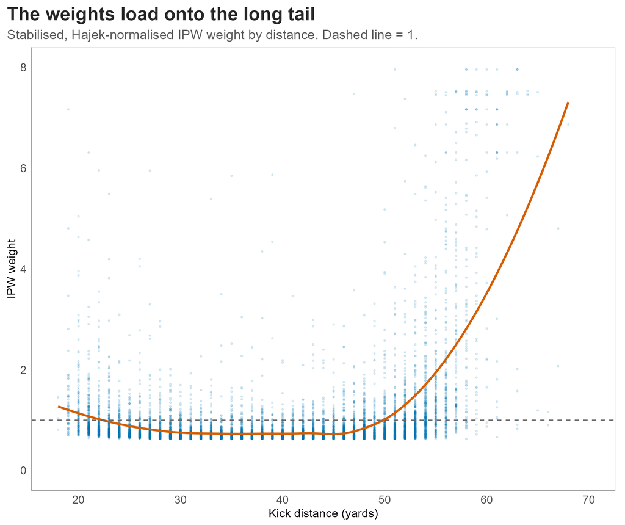

## The outcome model

- Seven-column B-spline in distance ($d_i$). Interior knots 28, 38, 48, 58. Boundaries 18 and 70.
- Natural splines, 3 df each, in standardized wind ($W_i$), temperature ($T_i$), and humidity ($H_i$).
- Contextual indicators ($\mathbf{C}_i$). Turf, precipitation, clock running, last two minutes, iced, playoffs.
- Kicker-season random intercept $u_{s(i)}$. Stadium random intercept $v_{g(i)}$.

$$\text{logit}\, P(\text{make}_i) = \sum_{k=1}^{7} \beta_k b_k(d_i) + \sum_{j} \gamma_j n_j(W_i, T_i, H_i) + \boldsymbol{\delta}^\top \mathbf{C}_i + u_{s(i)} + v_{g(i)}$$

Identical specification for M1, M2 and M3; only the training set and the case weights change.

## The ordering reverses

| Model | IS Brier | OOS Brier | IS Log-Loss | OOS Log-Loss |
| --- | --- | --- | --- | --- |
| M0 distance only | 0.1045 | 0.1012 | 0.3387 | 0.3323 |
| M1 full GLMM | 0.1004 | **0.1004** | 0.3259 | **0.3295** |
| M2 augmented | 0.1009 | 0.1013 | 0.3281 | 0.3323 |
| M3 IPW | **0.0982** | 0.1030 | **0.3216** | 0.3383 |

**M3 wins in-sample on every metric and loses out-of-sample on every metric.** Out of sample it is outperformed by the distance-only model.

## Calibration on held-out kicks

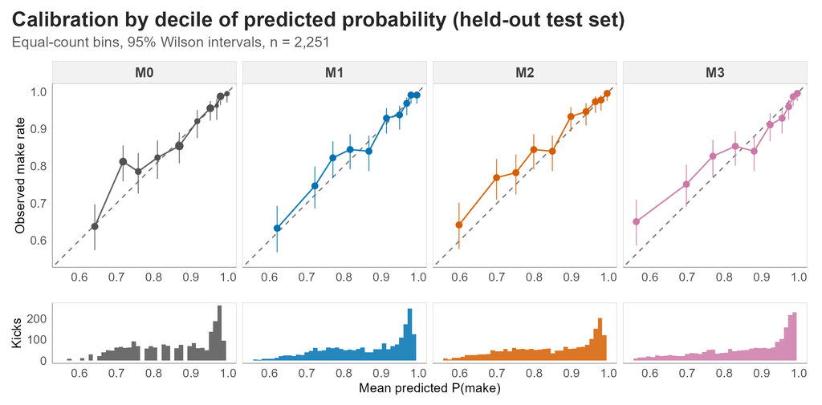

## Why neither correction wins

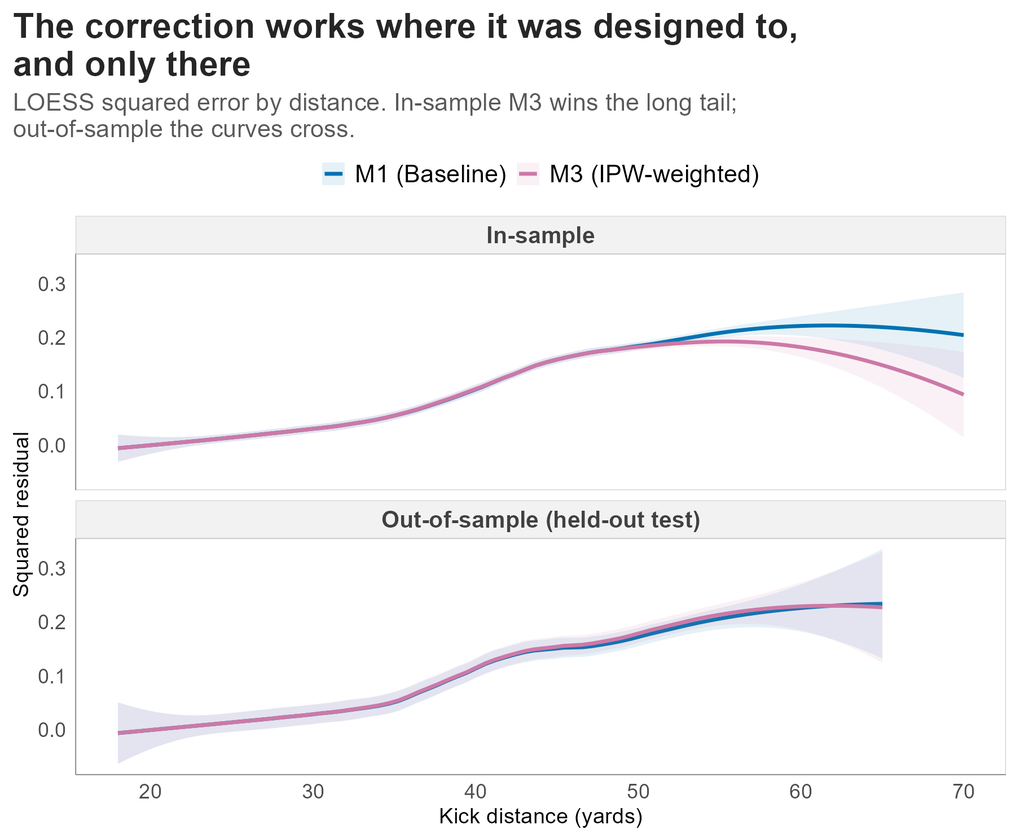

M1 Brier: IS 0.1004 / OOS 0.1004. M3 Brier: IS 0.0982 / OOS 0.1030.

**M2. The labels are systematically wrong.**

| Aug. weight | IS Brier |
| --- | --- |
| 0.05 | 0.1007 |
| 0.10 | 0.1009 |
| 0.25 | 0.1013 |

**M3. The weights concentrate fit on the sparsest part of the curve.**

Weight is concentrated on long, low-propensity attempts. In-sample error drops exactly there. Out of sample the curves cross.

## To kick or not to kick

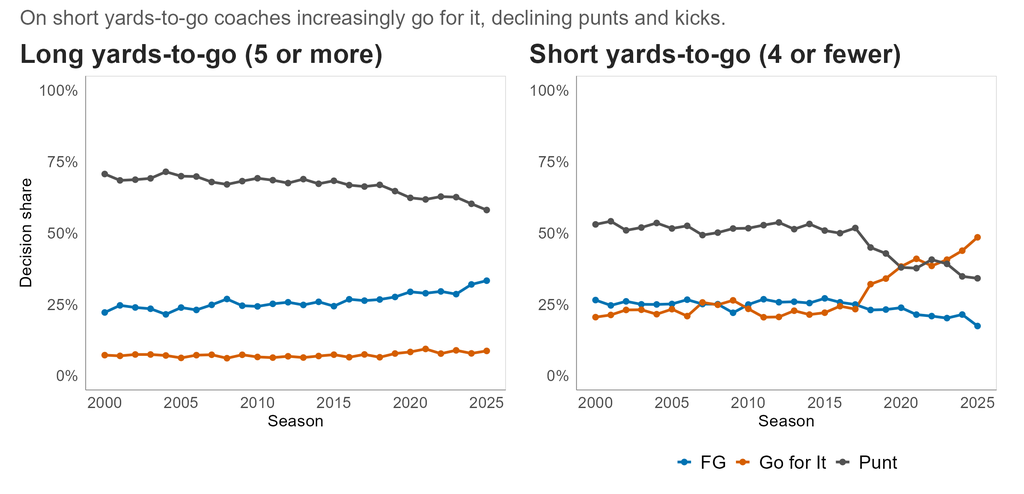

On long yards to go, field goals keep taking share from punts, in step with kicker improvement. On short yards to go, going for it surges after about 2018, a shift better kicking does not explain.

## Fourth and short, by era

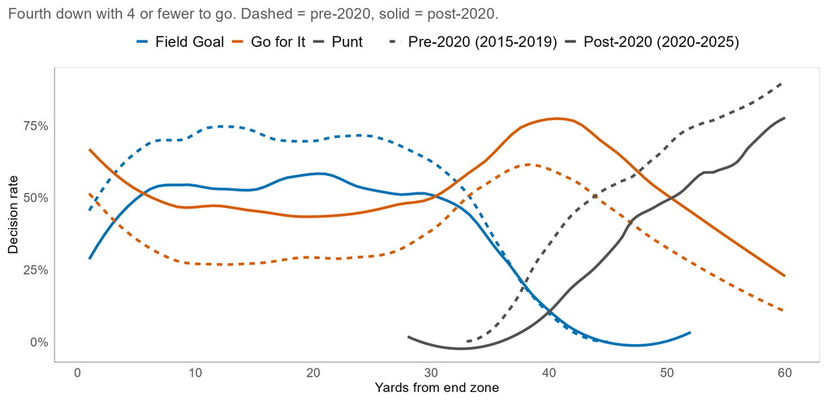

Post-2020, coaches go for it more at nearly every field position. If declines were about doubting the kicker, improving kickers should have moved these curves the other way.

## The value was in the alternative

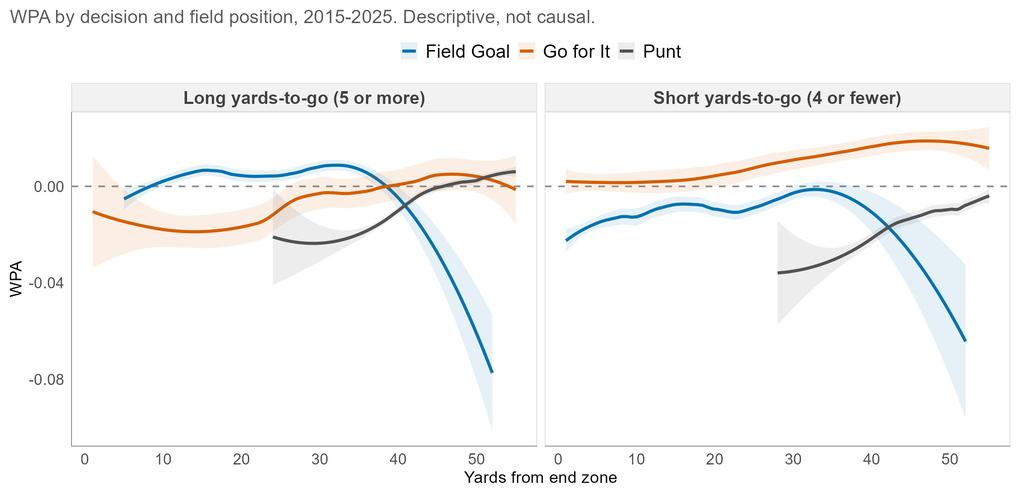

On short yards to go, going for it carries positive win probability added almost everywhere, while a field goal does not. The decline looks less like doubt about the kicker and more like taking the higher-value option.

## What we take from this

**Findings**

1. Coaching selection is strongly structured. In-range AUC 0.93 to 0.96 every season.
2. Pseudo-label augmentation fails, and fails worse the harder you lean on it.
3. IPW corrects what it claims to in-sample at long distance and still does not generalize. M1 is the better forecaster in both eras.

**Recommendation**

For in-game make probability, use the unweighted GLMM.

## What we take from this

**Findings**

1. Coaching selection is strongly structured. In-range AUC 0.93 to 0.96 every season.
2. Pseudo-label augmentation fails, and fails worse the harder you lean on it.
3. IPW corrects what it claims to in-sample at long distance and still does not generalize. M1 is the better forecaster in both eras.

**Recommendation**

For in-game make probability, use the unweighted GLMM.

**What that appears to say about the mechanism**

We assumed coaches decline out of doubt about the kicker. The decision curves and the WPA landscape point elsewhere. If the decision carries little information about kicker ability, there is little for a correction to recover.

**Next**

Kicker evaluation via an over-expected model. Coaching analysis via a win-probability-maximizing decision model. A causal treatment of the attempt decision.

## Thank you

**Questions welcome.**

Data via **nflfastR**.

Elliott Kervin · Michael Schuckers University of North Carolina at Charlotte

**Key references**

Pasteur and Cunningham-Rhoads, on distance-adjusted kicker evaluation.

Osborne and Levine, on shrinkage estimation of field goal success.

Horvitz and Thompson, on sampling without replacement from a finite universe.

Hernan and Robins, *Causal Inference*, on stabilized weights.

## New Diamond Open Access journal

**Journal of Statistics and Data Science in Sports**

*https://journals.charlotte.edu/index.php/jsdss*

[figure not shown]

## Train and test balance

Appendix A1

| Distance Band | Train n | Train share | Test n | Test share | Diff (pp) |
| --- | --- | --- | --- | --- | --- |
| < 30 | 2,214 | 23.8% | 495 | 22.0% | -1.82 |
| 30-39 | 2,654 | 28.5% | 644 | 28.6% | +0.06 |
| 40-49 | 2,716 | 29.2% | 696 | 30.9% | +1.71 |
| 50-59 | 1,636 | 17.6% | 397 | 17.6% | +0.04 |
| 60+ | 77 | 0.8% | 19 | 0.8% | +0.02 |
| **Mean kick distance** |  | 38.68 |  | 39.00 | +0.32 yds |

Season-stratified game-level permutation test on the band shares, 2,000 redraws. Observed total variation distance 0.0182, null median 0.0162, $p = 0.385$. The realized split is an unremarkable draw.

## Era stability of the result

Appendix A2

| Era | M1 Brier | M3 Brier | M1 Log-Loss | M3 Log-Loss |
| --- | --- | --- | --- | --- |
| Pre-2020 (n = 976) | **0.1105** | 0.1141 | **0.3583** | 0.3702 |
| Post-2020 (n = 1,275) | **0.0928** | 0.0945 | **0.3074** | 0.3139 |

M1 beats M3 in both halves, on both scoring rules. The result is not a post-2020 artifact.

## Full results

Appendix A3

| Model | IS Brier | IS Log-Loss | IS AUC | OOS Brier | OOS Log-Loss | OOS AUC |
| --- | --- | --- | --- | --- | --- | --- |
| M0 distance only | 0.1045 | 0.3387 | 0.774 | 0.1012 | 0.3323 | 0.762 |
| M1 full GLMM | 0.1004 | 0.3259 | 0.804 | **0.1004** | **0.3295** | **0.769** |
| M2 augmented | 0.1009 | 0.3281 | 0.800 | 0.1013 | 0.3323 | 0.766 |
| M3 IPW | **0.0982** | **0.3216** | **0.805** | 0.1030 | 0.3383 | 0.757 |

In-sample $n = 11{,}548$. Held-out $n = 2{,}251$. Brier and log-loss lower is better, AUC higher is better. Blocked kicks excluded.

## Where exactly M3 improved

Appendix A4

| Distance Band | n | M0 | M1 | M2 | M3 |
| --- | --- | --- | --- | --- | --- |
| < 30 | 2,709 | 0.0162 | 0.0161 | 0.0161 | 0.0161 |
| 30-39 | 3,298 | 0.0553 | **0.0543** | 0.0545 | 0.0545 |
| 40-49 | 3,412 | 0.1563 | **0.1502** | 0.1508 | 0.1503 |
| 50-59 | 2,033 | 0.2090 | 0.1981 | 0.1996 | **0.1879** |
| 60+ | 96 | 0.2298 | 0.2188 | 0.2193 | **0.1657** |

In-sample Brier by distance band. Bands are half-open, so 60+ means 60 yards or more. M3 gains 5.2% at 50-59 and 24.3% at 60+ versus M1.

## Why the lowest decile sits near 60%

Appendix A5

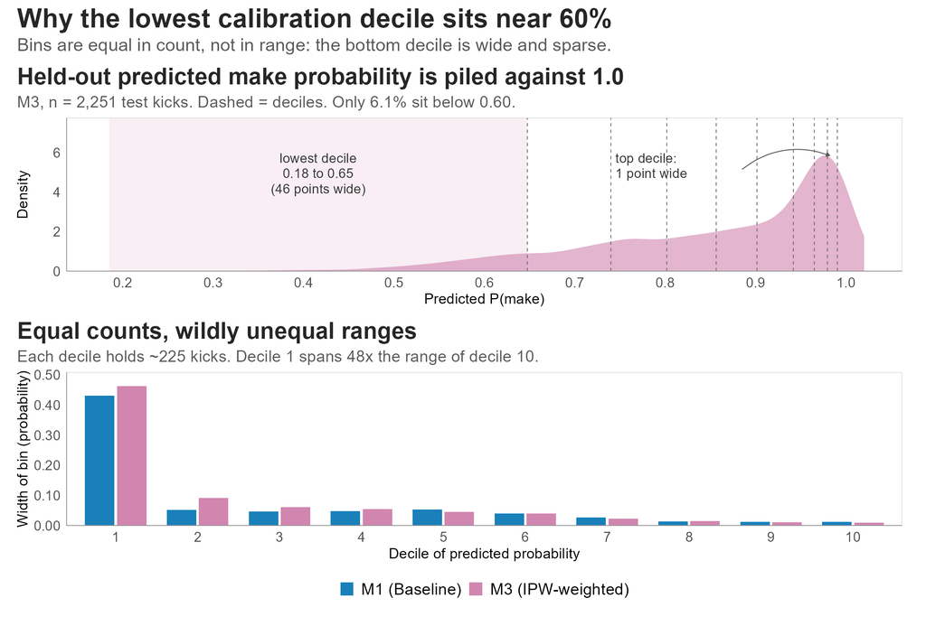

## Weight construction in full

Appendix A6

**Three stages, per season**

1. Stabilize. $w_i = \bar{\pi} / \hat{\pi}(X_i)$, with $\hat{\pi}$ clipped to $[0.02, 0.98]$ before inversion.
2. Hajek-normalize to mean 1, then cap at $\bar{w}_s + 3\sigma_{w,s}$, then renormalize.
3. $\bar{\pi}$ and both normalizations are computed over the **in-range** subset, not the full propensity frame.

**What the cap costs and buys**

Before capping, one attempt carried a case weight of **1,633**.

After capping, weights span **0.63 to 8.49**, median 0.71.

Effective sample size falls from 11,764 to about **6,300**, so the reweighting costs roughly 46% of the sample.

## M2 inclusion criteria

Appendix A7

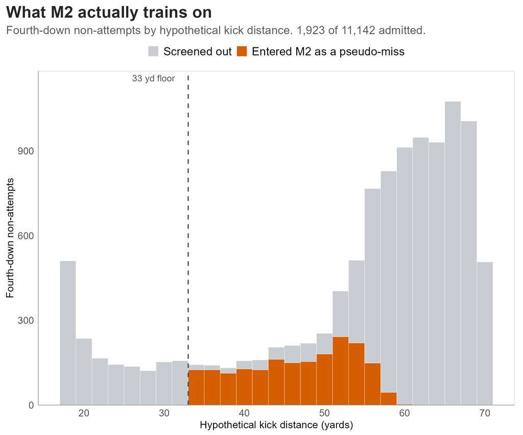

Primary screen: propensity at least 0.25 and distance beyond 33 yards. 1,923 of 11,142 candidates admitted, with pseudo-miss labels biased in a known direction.

| Propensity floor | Pool | OOS Brier |
| --- | --- | --- |
| M1, no augmentation | 0 | **0.1004** |
| 0.50 | 1,087 | 0.1009 |
| 0.35 | 1,543 | 0.1012 |
| 0.25 (primary) | 1,923 | 0.1013 |
| 0.15 | 2,470 | 0.1016 |
| 0.10 | 2,903 | 0.1018 |

Monotone, and in the unhelpful direction. Every step down in the floor makes it worse, and the limit of the sweep is no augmentation at all.

## M2 weight sensitivity in full

Appendix A8

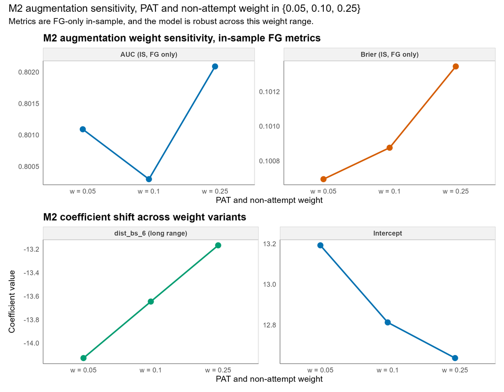

## Weather covariates, raw

Appendix A9a

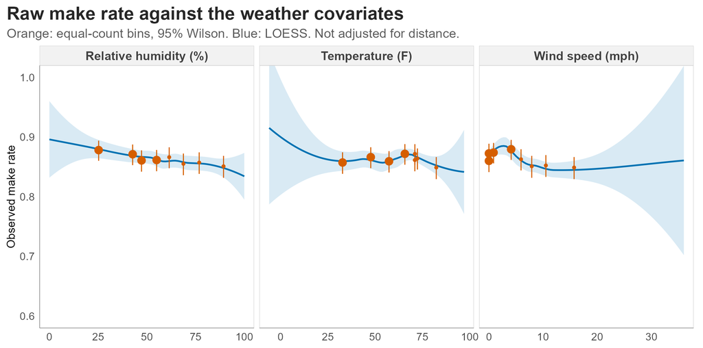

## Weather covariates, distance held

Appendix A9b

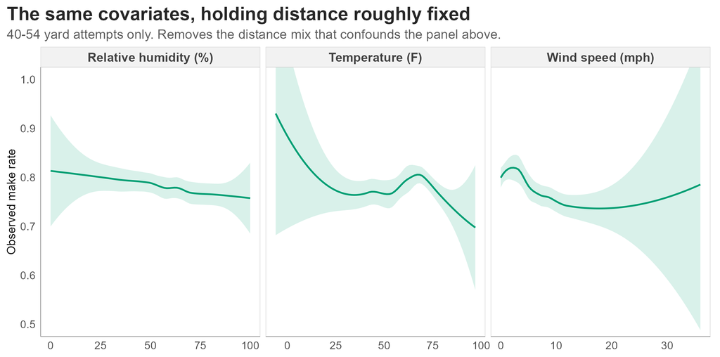

## Fourth-down decisions by field position

Appendix A10

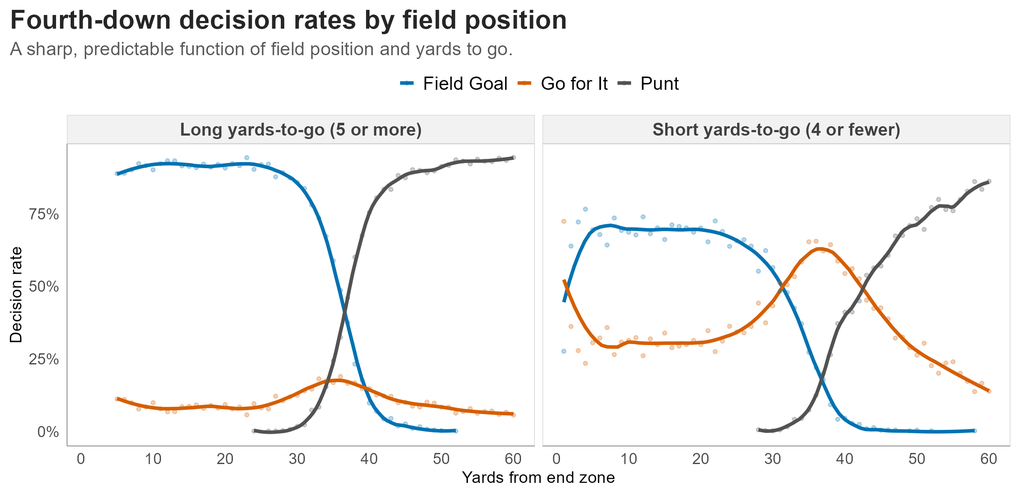

## In-sample separation

Appendix A11

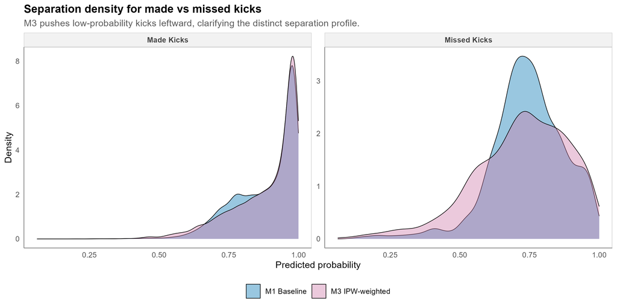

## WPA by regime and era

Appendix A12

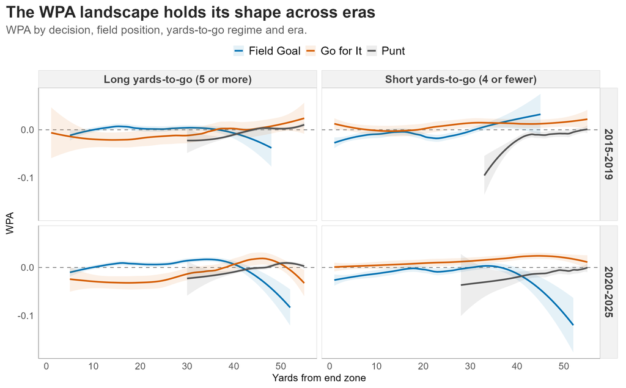

## Open questions

Appendix A13

**Speculation, not analysis**

Why did fourth-down behavior change so sharply around 2018 to 2020? Coaching trees, the spread of analytics staff, and public win-probability tools are all plausible and none of them are tested here.

Whether the shift is better described as a change in beliefs or a change in willingness to act on beliefs already held.

**What a causal treatment would need**

An estimand defined on the decision itself rather than on the observed attempts.

An identification argument for unmeasured coach and roster factors, which the propensity model conditions on only through their observable proxies.

A defensible answer to what “would have happened” means for a kick that was never taken.